# STAT/MATH 495: Problem Set 06

Luke Haggerty

2017-10-17

# Collaboration

Please indicate who you collaborated with on this assignment: Individual

# Setup

Define truth, which again we know for the purposes of this assignment, but in practice we won’t:

- the true function f(x) i.e. the signal
- the true epsilon i.e. the noise, which in this case is Normal$(0, sd=\sigma)$. Hence the standard deviation $\sigma$ determines the amount of noise.

```r
f <- function(x) {
  x^2
}
sigma <- 0.3
```

This is the target point we’ll be trying to predict: $(0.95, f(0.95)) = (0.95, 0.95^2) = (0.95, 0.9025)$, Thus, the test set is just `x=0.95`

```r
x0 <- 0.95
test_set <- data_frame(x=x0)
```

This function generates a random sample of size $n$; think of this as a “get new data” function. Random in terms of both:

- (New) the predictor x (uniform on [0,1])
- the amount of noise $\epsilon$

```r
generate_sample <- function(f, n, sigma) {
  sample <- data_frame(
    x = runif(n, min = 0, max = 1),
    f_x = f(x),
    epsilon = rnorm(n = n, mean = 0, sd = sigma),
    y = f_x + epsilon
  )
  # Recall: We don't observe f(x) and epsilon, just (x, y)
  sample <- sample %>%
    select(x, y)

  return(sample)
}
```

Define

- The number $n$ of observations $(x_i, y_i)$ in each sample. In the handout, $n=100$ to keep plots uncrowded. Here we boost to $n=500$
- Number of samples of size $n$ to consider

```r
n <- 500
n_sample <- 10000
```

# Computation

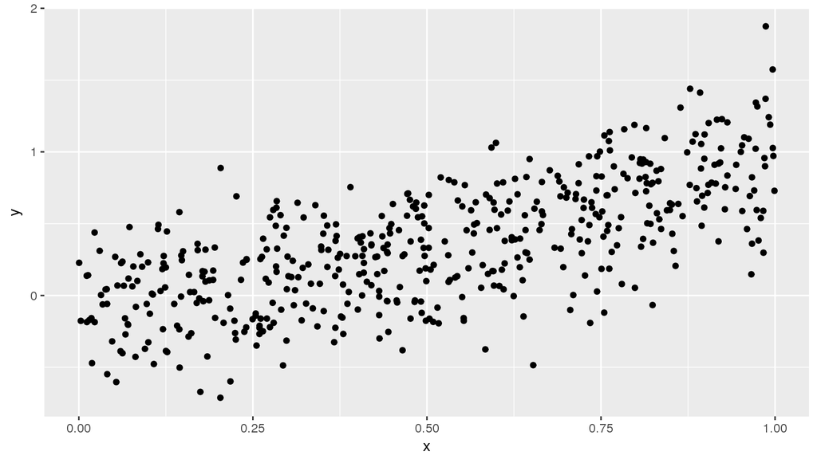

```r
train_set <- generate_sample(f,n,sigma)

ggplot(data = train_set, aes(x = x, y = y)) + geom_point()
```

```r
model1<-smooth.spline(train_set$x, train_set$y, df=2)
model2<-smooth.spline(train_set$x, train_set$y, df=99)


model1predict <- predict(model1, x=x0)
model2predict <- predict(model2, x=x0)

MSE1<- (x0^2-model1predict$y)^2
MSE2<- (x0^2-model2predict$y)^2
Bias1 <- model1predict$y - x0^2
Bias2 <- model2predict$y - x0^2

MSE1
```

```
## [1] 0.006823463
```

```r
MSE2
```

```
## [1] 0.001281667
```

```r
Bias1
```

```
## [1] -0.08260426
```

```r
Bias2
```

```
## [1] 0.03580038
```

# Tables

As done in Lec 2.7, for both

- An `lm` regression AKA a `smooth.splines(x, y, df=2)` model fit
- A `smooth.splines(x, y, df=99)` model fit

output tables comparing:

[output not shown]

where `sum = bias_squared + var + irreducible`. You can created cleanly formatted tables like the one above by piping a data frame into `knitr::kable(digits=4)`.

# Analysis

**Questions**:

1. Based on the topics covered in Lec 2.7, name one possible “sanity check” for your results. Name another if you can.
2. In **two** sentences or less, give a rough sketch of what the procedure would be to get the breakdown of
   $$\mbox{MSE}\left[\widehat{f}(x)\right]$$
   for *all* $x$ in this example, and not just for
   $$\mbox{MSE}\left[\widehat{f}(x_0)\right]
   = \mbox{MSE}\left[\widehat{f}(0.95)\right]$$
   .
3. Which of the two models would you choose for predicting the point of interest and why?

**Answers**: